# Pine_development

Carl Vigren

```r
library(forester)
library(tidyverse)
```

# How do we calculate the volume of a stand?

We usually only have the following information:

- Dominant height
- Diameter. Height is too difficult to measure for every tree.
- Stem density
- Basal area including bark, m<sup>2</sup>/<sub>ha</sub>

Because the mean height of a stand is very sensitive to different forestry operations, we have adopted a measure of the maximum attained height instead: **dominant height**.

Firstly, you should now that the dominant height of a stand has had many differing definitions:

- The mean height of the 100 tallest trees per stand unit.
- The mean height of the two trees with the thickest diameters.
- The mean height of the top x % tallest trees.

Let’s create som random data to demonstrate how the two variables compare.

Create 200 dummy data observations following a normal distribution with a mean of 6 metres and a standard deviation of 2.5 metres.

```r
norm_distr <- data.frame(rnorm(200, mean=6, sd=2.5))
norm_distr <- norm_distr %>% rename(height = rnorm.200..mean...6..sd...2.5.)
```

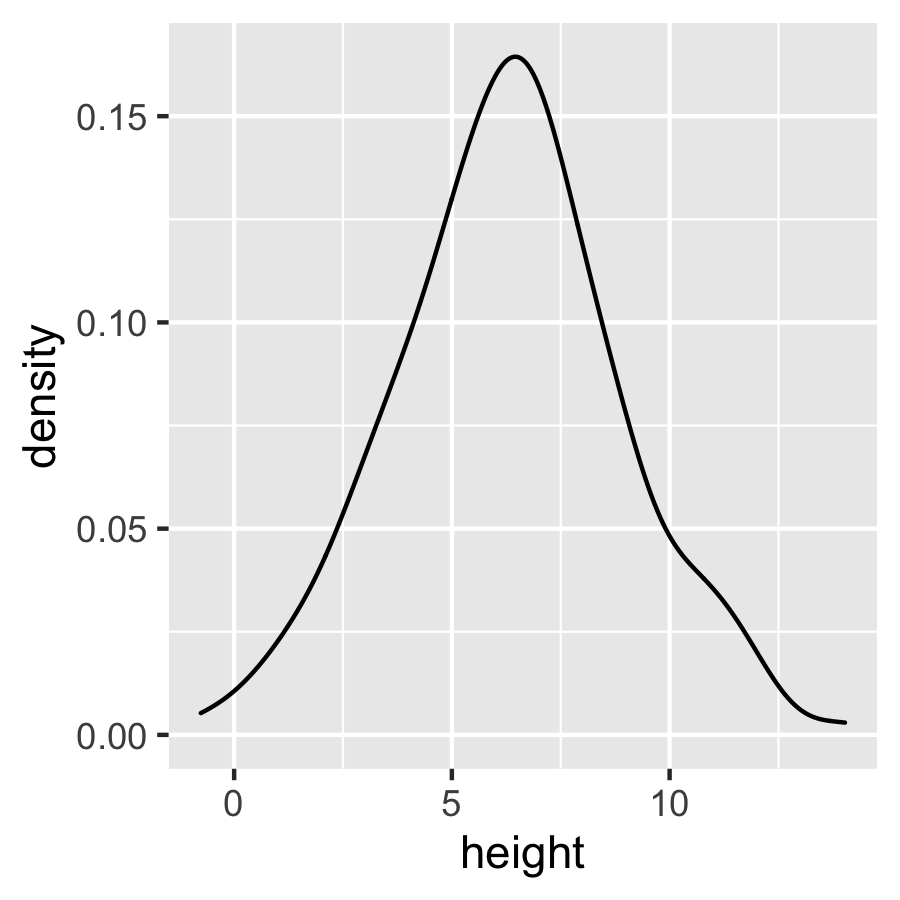

```r
norm_distr %>% ggplot(aes(x=height)) + geom_density()+theme(legend.position="bottom")
```

```r
norm_distr_summary <- norm_distr %>% summarise(mean_stand_height=mean(height), dominant_height=quantile(height,probs=0.9, names=FALSE))
norm_distr_summary
```

```
#>   mean_stand_height dominant_height
#> 1          6.295138        9.559552
```

Let’s see how they are affected by a low-grading thinning (removing the suppressed trees).

```r
norm_thinned <- norm_distr %>% filter(height > quantile(height, probs=0.3))

norm_thinned_summary <- norm_thinned %>% summarise(mean_stand_height=mean(height), dominant_height=quantile(height,probs=0.9,names=FALSE))
norm_thinned_summary
```

```
#>   mean_stand_height dominant_height
#> 1          7.565383        10.44161
```

What do the distributions look like now?

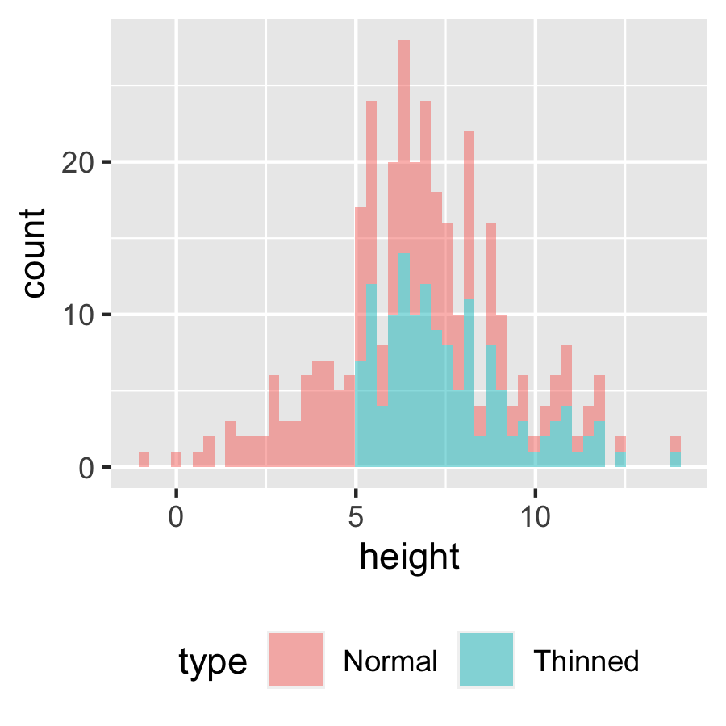

```r
#Create identifying variables
norm_distr <- norm_distr %>% mutate(type="Normal")
norm_thinned <- norm_thinned %>% mutate(type="Thinned")

# Append the tables.
distr_joined <- rbind(norm_distr, norm_thinned)

#Plot the distributions of the stand before and after the low-grading.
distr_joined %>% ggplot(aes(x=height,fill=type))+geom_histogram(alpha=0.5, bins=50)+theme(legend.position="bottom")
```

Let’s calculate the percentual change in our variables:

```r
#mean stand height
((norm_thinned_summary[1,1]/norm_distr_summary[1,1])-1)*100
```

```
#> [1] 20.17819
```

```r
#dominant stand height
((norm_thinned_summary[1,2]/norm_distr_summary[1,2])-1)*100
```

```
#> [1] 9.226964
```

That’s a large difference in the percentual increase! Dominant height seems like a better variable to track the *potential* height growth of a stand.

But what does this have to do with the total volume produced in a stand?! Easy tiger, we’re getting there!

# Height ~ Diameter relationship

Trees, unlike us, have an unlimited amount of organs - each year they grow new appendages in the form of leaves, branches, and a new shoot. To support their height growth, they also have cambial growth - which soon enough dies, and is transformed into Xylem. Trees increase their diameter with age.

Can we model what this relationship looks like?

Here’s some data on tree heights (m) and diameters (mm)

A number of Spruce heights and diameters from a stand

| diameter | height |
| --- | --- |
| 1 | 1.234725 |
| 16 | 1.743220 |
| 31 | 2.898900 |
| 46 | 3.562612 |
| 61 | 4.994880 |

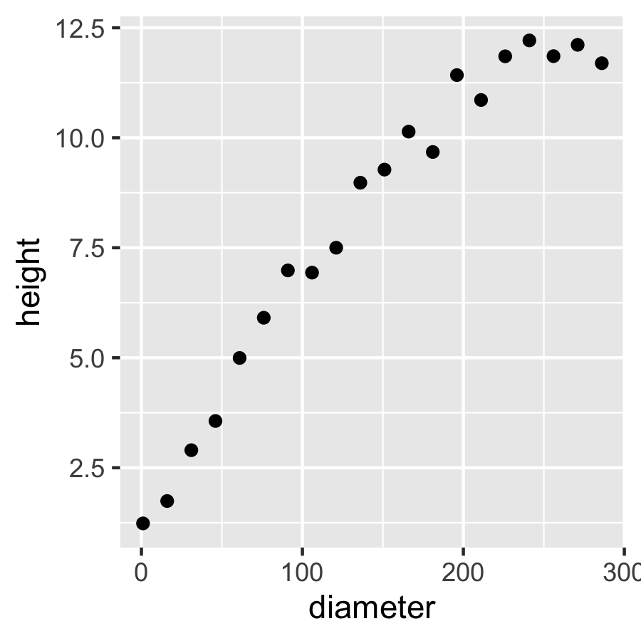

```r
Spruce_height_diameter %>% ggplot()+geom_point(aes(x=diameter,y=height))
```

```r
Spruce_height_diameter <- Spruce_height_diameter %>% mutate(species="Spruce") %>% group_by(species) %>% nest() %>%  mutate(
  model= map(data, ~nls(height ~ 1.3 + I(diameter^2)/I((a+ b*diameter)^2), start=list(a=1,b=1),data=.))) %>%
  # extract formula from each model, convert to one-sided form, &
  # replace coefficients with fitted values, & store in dataframe
  # as character string
  rowwise() %>%
  mutate(func = formula(model) %>%
           as.character() %>%
           magrittr::extract(3) %>%
           gsub("diameter", ".x", ., fixed = T) %>%
           gsub("a", model$m$getPars()[1], .) %>%
           gsub("b", model$m$getPars()[2], .) %>%
           paste("~", ., collapse = "")) %>%
  ungroup()

print(Spruce_height_diameter)
```

```
#> # A tibble: 1 x 4
#>   species          data model  func
#>   <chr>   <list<df[,2]> <list> <chr>
#> 1 Spruce       [20 × 2] <nls>  ~ 1.3 + I(.x^2)/I((17.7392626090973 + 0.23685949…
```

Let’s see what it looks like.

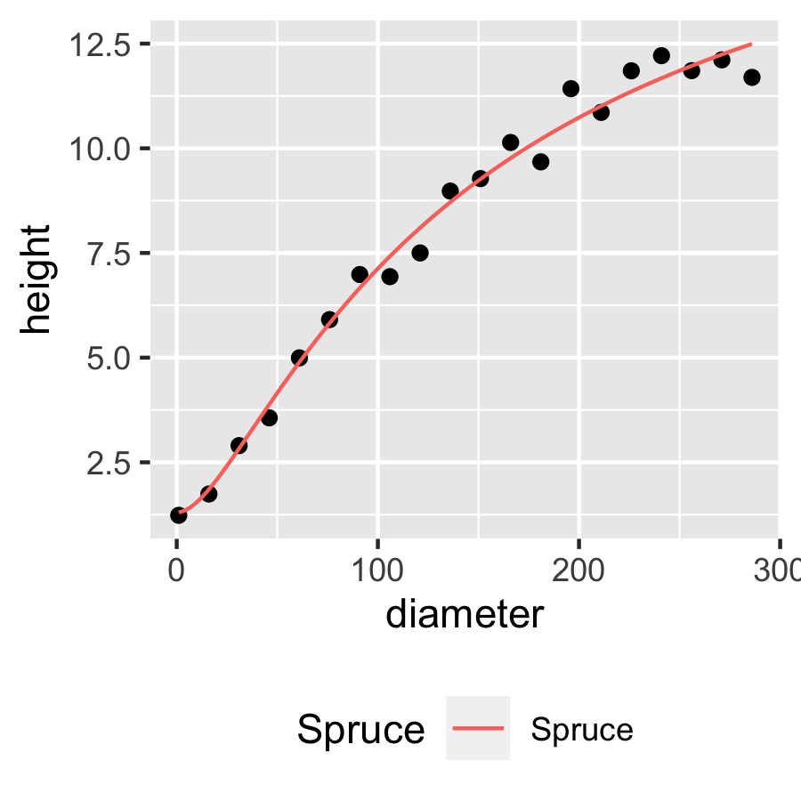

```r
ggplot(Spruce_height_diameter[[2]][[1]])+
  theme(legend.position = "bottom")+
  geom_point(aes(x=diameter,y=height)) + #All the data
    # add formula in each row as a separate geom_function layer
  lapply(seq(1, nrow(Spruce_height_diameter)),
         function(i) geom_function(fun = rlang::as_function(formula(Spruce_height_diameter$func[i])),
                                   aes(colour = Spruce_height_diameter$species[i]))) +

  # change legend name (can also change palette / labels / etc.)
  scale_colour_discrete(name = "Spruce")
```

Great! Now we can predict the heights of all measured trees in our stand from the representative subset we measured!

```r
forester::plant_spacing(stems_per_ha = 4400)
```

```
#> [1] 1.507557
```

We’ve measured the tree diameters:

```r
#We assume normal diameter distribution
diameters <- data.frame(diameters= rnorm(4000, mean=130, sd=50))

#The stand has been heavily thinned from below (40%)
diameters <- diameters %>% filter(diameters > quantile(diameters, probs=0.4))
```

```r
diameters <- diameters %>% mutate(height= 1.3 + diameters^2/(19.1265151455858 + 0.229470870878339 * diameters)^2)
```

Now that we have the diameters and heights of all stems, we can approximate the volume of the stand with help of the `forester::tree.volume` function.

```r
diameters <- diameters %>% mutate(volume= tree.volume(dbh.cm=diameters/10, height.m=height,species.latin="Picea abies", latitude = 65))
```

The total stand standing volume is (dm^3):

```r
diameters %>% summarise("Total volume" = sum(volume))
```

```
#>   Total volume
#> 1     246864.6
```

In order to get m^3 from dm^3, divide by 1’000.

```r
diameters %>% mutate(volume_m3 = volume / 1000) %>% summarise("Total volume"= sum(volume_m3))
```

```
#>   Total volume
#> 1     246.8646
```